# FlaringABM market history

Nick Willems

CHARACTERIZE WELL COST INFLATION.

CHARACTERIZE HISTORICAL NATURAL GAS AND OIL MARKETS. NAMELY, DETERMINE THE PRICE RELATIONSHIP BETWEEN OIL AND GAS AND FORMULATE REPRESENTATIVE NATURAL GAS DEMAND FUNCTIONS.

CHARACTERIZE GREEN ELECTRICITY DEMAND AS ANALOGY TO GREEN GAS.

```r
library(data.table)
library(readxl)
library(ggplot2)
```

# Upstream cost index

MIT: The future of geothermal energy (pg 6-13 & 6-34) presents an oil & gas well cost index that only includes onshore wells. [EIA](https://www.eia.gov/dnav/ng/NG_ENR_WELLCOST_S1_A.htm) presents a cost index with more historical data, but it is not clear whether offshore wells are also included.

```r
MIT_index <- fread("./data/MIT_composite_index.csv")
MIT_index[, "source":= "MIT"]

EIA_index <- read_xls("./data/NG_ENR_WELLCOST_S1_A.xls", sheet="Data 1", skip=2)
setDT(EIA_index)
EIA_index[, "source":= "EIA"]
EIA_index[, "year":= as.numeric(substr(Date, 1, 4))]

EIA_index[, "nom_index_1977":= 100 * .SD / .SD[year==1977][[1]],
    .SDcols="U.S. Nominal Cost per Crude Oil, Natural Gas, and Dry Well Drilled (Thousand Dollars per Well)"]

well_cost_index <- rbind(EIA_index[, .(year, nom_index_1977, source)], MIT_index)[order(year)]

well_cost_index[, "composite":= (source=="MIT" & year>=1976) | (source=="EIA" & !between(year, 1976, 2004))]
```

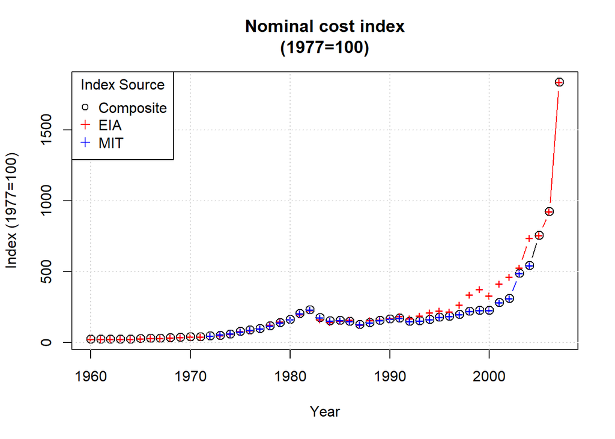

Very strong agreement between EIA & MIT cost indices prior to 1992

```r
color_scheme <- c("Composite"="black", "EIA"="red", "MIT"="blue")
plot(nom_index_1977 ~ year, well_cost_index[composite==TRUE], type="b", col=color_scheme[1], cex=1.3,
    main="Nominal cost index\n(1977=100)", xlab="Year", ylab="Index (1977=100)")
lapply(unique(well_cost_index$source), function(x)
    points(nom_index_1977 ~ year, well_cost_index[source==x], type="b", col=color_scheme[x], pch="+"))
grid()
legend("topleft", names(color_scheme), col=color_scheme, pch=c(1,3,3), title="Index Source")
```

```r
well_cost_index[EIA_index, on="year",
    "scaler":=  `U.S. Real Cost per Crude Oil, Natural Gas, and Dry Well Drilled (Thousand Dollars per Well)` /
                `U.S. Nominal Cost per Crude Oil, Natural Gas, and Dry Well Drilled (Thousand Dollars per Well)`]
well_cost_index[, "real_index_1977":= nom_index_1977 * (scaler / scaler[year==1977]), by=source]

well_cost_index[, "real_index_2005":= real_index_1977 / real_index_1977[year==2005]]
```

[IEA](https://www.iea.org/data-and-statistics/charts/iea-us-shale-upstream-cost-index-2005-2020) have a third upstream cost index for US shale.  
[US EIA](https://www.eia.gov/analysis/studies/drilling/) & [IEA](https://www.iea.org/data-and-statistics/charts/iea-us-shale-upstream-cost-index-2005-2020) draw similar conclusions about historical cost data (e.g., 2015 costs were ~30% lower than 2012 values).

```r
IEA_index <- fread(text=   "year, real_index_2005
                            2005, 100
                            2006, 118.7
                            2007, 128.5
                            2008, 141.2
                            2009, 108
                            2010, 125.1
                            2011, 141.6
                            2012, 133.7
                            2013, 130.4
                            2014, 130.1
                            2015, 97.5
                            2016, 83.4
                            2017, 90.5
                            2018, 101.2
                            2019, 99.7")

IEA_index[, "real_index_2005":= real_index_2005/100]
IEA_index[, "source":= "IEA"]
```

```r
well_cost_index <- rbind(well_cost_index, IEA_index, fill=TRUE)[order(year)]
well_cost_index[, "composite":= (source=="MIT" & year>=1976) |
                                (source=="EIA" & year<1976) |
                                (source=="IEA")]
```

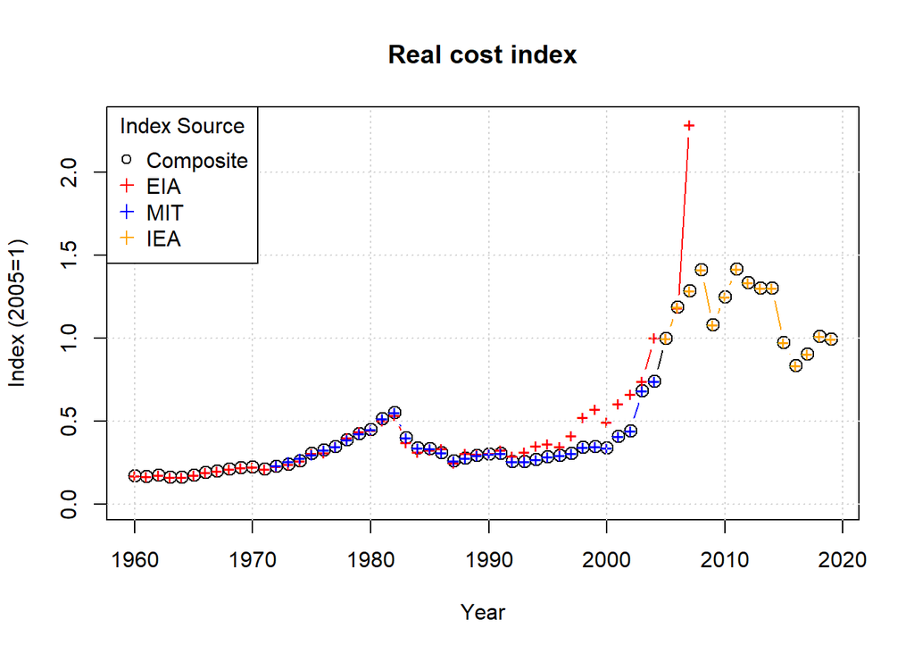

Close agreement between EIA & IEA cost indices for 2005, 2006

```r
color_scheme <- c(color_scheme, c("IEA"="orange"))
plot(real_index_2005 ~ year, well_cost_index[composite==TRUE], type="b", col=color_scheme[1], cex=1.3, ylim=c(0,2.3),
    main="Real cost index", xlab="Year", ylab="Index (2005=1)")
lapply(unique(well_cost_index$source), function(x)
    points(real_index_2005 ~ year, well_cost_index[source==x], type="b", col=color_scheme[x], pch="+"))
grid()
legend("topleft", names(color_scheme), col=color_scheme, pch=c(1,3,3,3), title="Index Source")
```

Output the composite 2014 index

```r
well_cost_index[, "real_index_2014":= real_index_2005 / real_index_2005[year==2014]]

fwrite(well_cost_index[composite==TRUE, .(year, source, real_index_2014)], "./processed/well_cost_index.csv")
```

# Historical Prices

[Natural gas (Henry Hub)](https://www.eia.gov/dnav/ng/NG_PRI_FUT_S1_M.htm), [Oil (West Texas Intermediate)](https://www.eia.gov/dnav/pet/hist/rwtcW.htm)

```r
HH <- fread("./data/Henry_Hub_Natural_Gas_Spot_Price_weekly.csv")

WTI <- fread("./data/Cushing_OK_WTI_Spot_Price_FOB.csv")
```

```r
daily_prices <- na.omit(WTI[HH, on="Day"])
daily_prices[, "Day":= as.Date(Day, format='%m/%d/%Y')]
daily_prices[, "year":= as.numeric(format(Day, "%Y"))]

setnames(daily_prices, "Cushing OK WTI Spot Price FOB  Dollars per Barrel",          "dollars_pBBL")
setnames(daily_prices, "Henry Hub Natural Gas Spot Price Dollars per Million Btu",   "dollars_pMMBTU")

# Convert million BTU to thousand cubic feet
daily_prices[, "dollars_pMCF":= 1.037 * dollars_pMMBTU]

daily_prices[, "ratio_BBLpMCF":= dollars_pBBL / dollars_pMCF]
daily_prices <- daily_prices[ratio_BBLpMCF>0]
```

## Natural gas prices

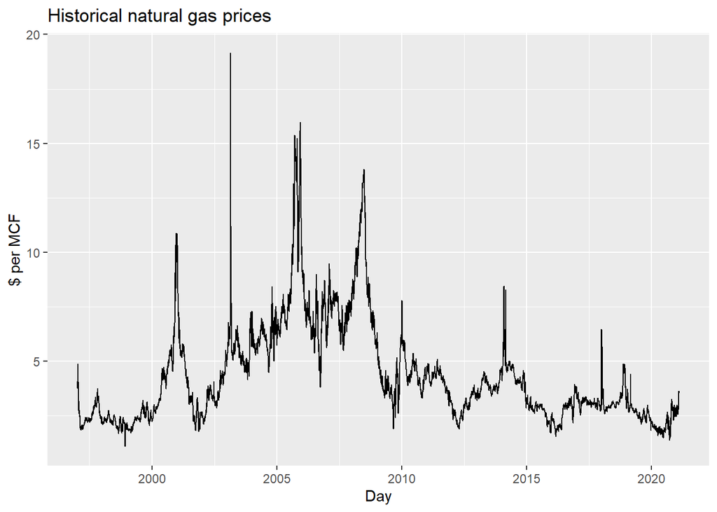

```r
ggplot(daily_prices, aes(x=Day, y=dollars_pMCF)) +
    geom_line() +
    labs(title="Historical natural gas prices", y="$ per MCF")
```

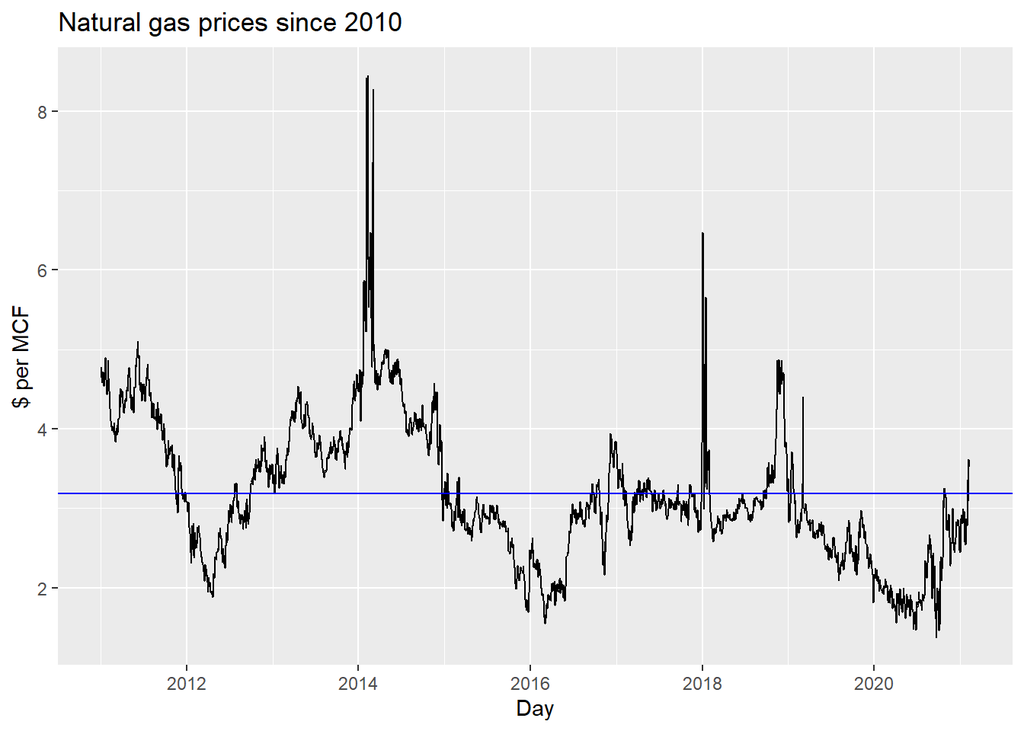

```r
ggplot(daily_prices[year>2010], aes(x=Day, y=dollars_pMCF)) +
    geom_line() +
    geom_hline(aes(yintercept=mean(dollars_pMCF)), color="blue") +
    labs(title="Natural gas prices since 2010", y="$ per MCF")
```

```r
daily_prices[year>2010,
                    .("Mean"= mean(dollars_pMCF), "Median"= median(dollars_pMCF), "Std Dev"= sd(dollars_pMCF))]
```

| Mean | Median | Std Dev |
| --- | --- | --- |
| 3.185939 | 3.02804 | 0.8760912 |

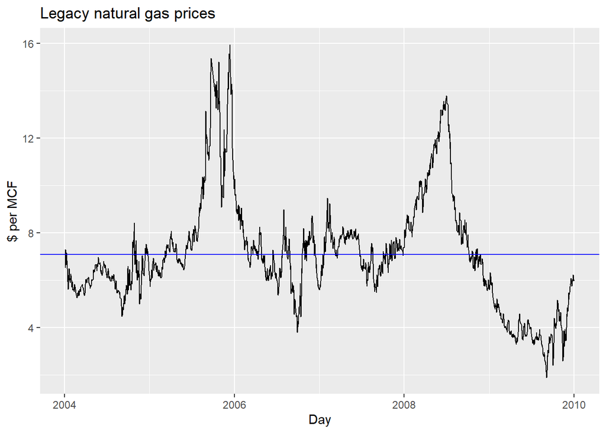

```r
ggplot(daily_prices[year>2003 & year<2010], aes(x=Day, y=dollars_pMCF)) +
    geom_line() +
    geom_hline(yintercept = mean(daily_prices[year>2003 & year<2010]$dollars_pMCF), color="blue") +
    labs(title="Legacy natural gas prices", y="$ per MCF")
```

```r
daily_prices[year>2003 & year<2010,
                    .("Mean"= mean(dollars_pMCF), "Median"= median(dollars_pMCF), "Std Dev"= sd(dollars_pMCF))]
```

| Mean | Median | Std Dev |
| --- | --- | --- |
| 7.090009 | 6.86494 | 2.351227 |

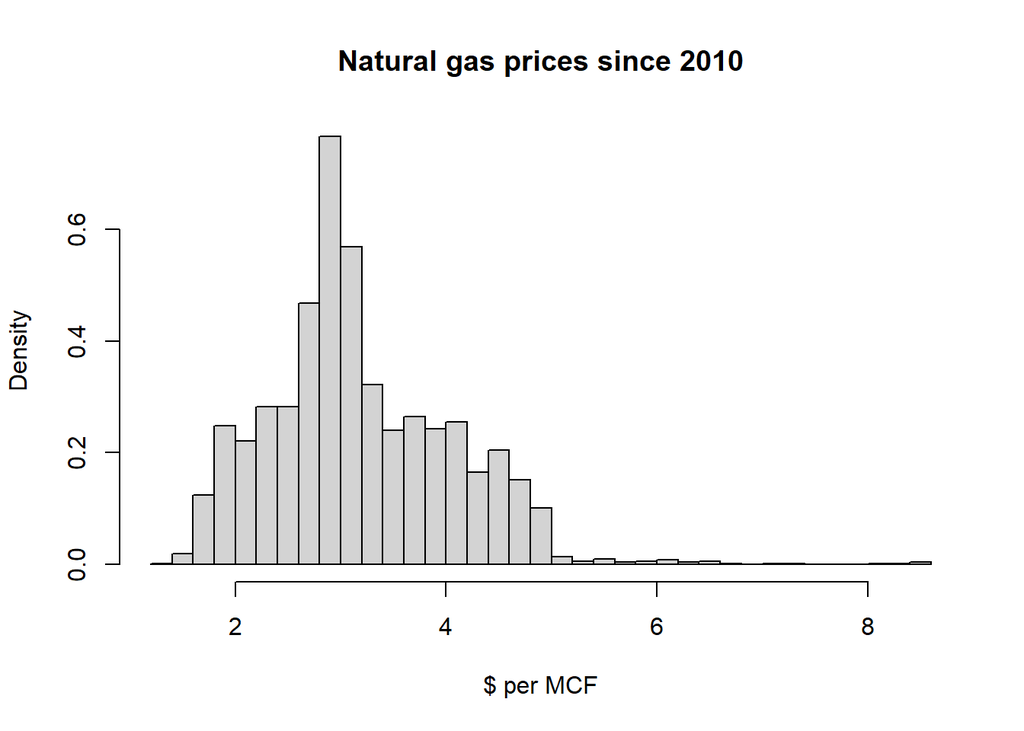

```r
daily_prices[year>2010, {hist(dollars_pMCF, freq=FALSE, breaks="scott", main="", xlab="");
                        title(main="Natural gas prices since 2010", xlab="$ per MCF"); NULL}]
```

## Ratio of oil and natural gas prices

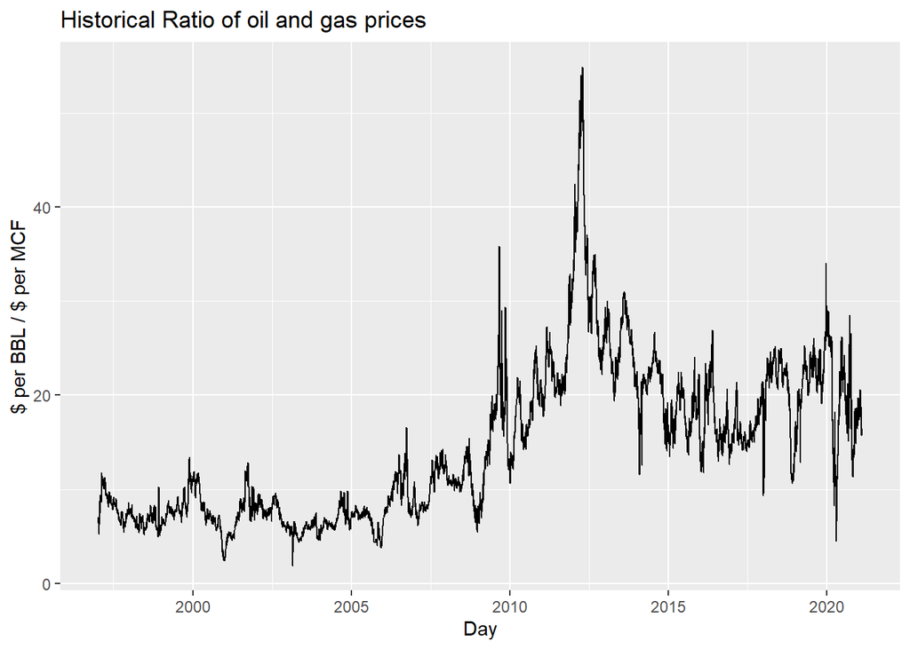

```r
ggplot(daily_prices, aes(x=Day, y=ratio_BBLpMCF)) +
    geom_line() +
    labs(title="Historical Ratio of oil and gas prices", y="$ per BBL / $ per MCF")
```

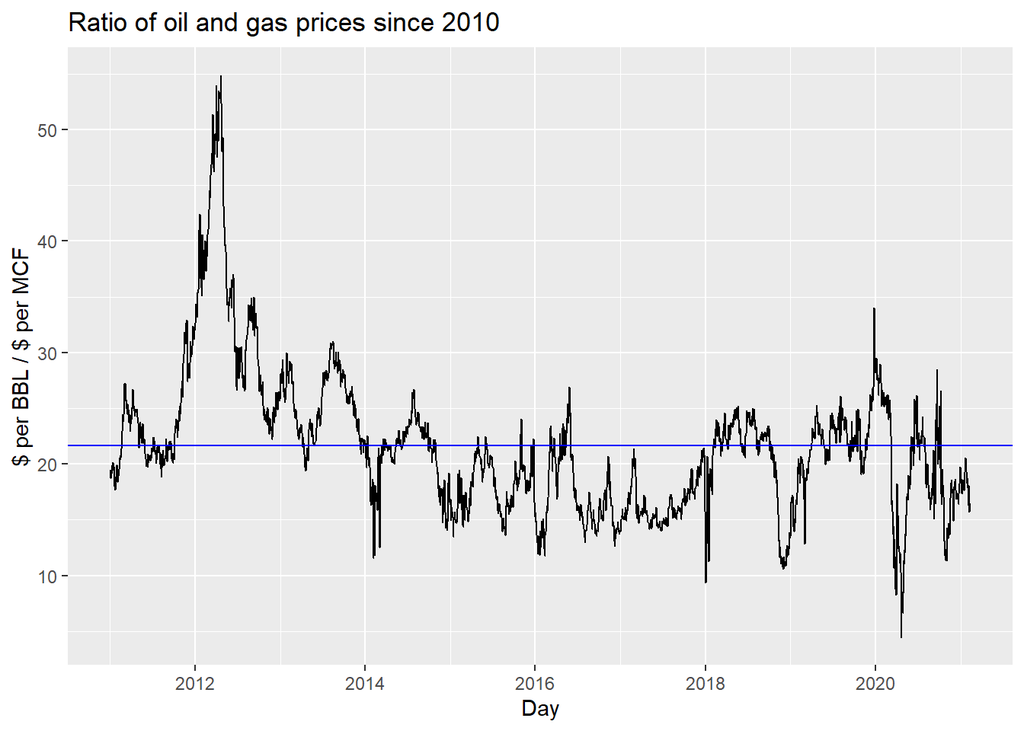

```r
ggplot(daily_prices[year>2010], aes(x=Day, y=ratio_BBLpMCF)) +
    geom_line() +
    geom_hline(aes(yintercept = mean(ratio_BBLpMCF)), color="blue") +
    labs(title="Ratio of oil and gas prices since 2010", y="$ per BBL / $ per MCF")
```

```r
daily_prices[year>2010,
                    .("Mean"= mean(ratio_BBLpMCF), "Median"= median(ratio_BBLpMCF), "Std Dev"= sd(ratio_BBLpMCF))]
```

| Mean | Median | Std Dev |
| --- | --- | --- |
| 21.66226 | 21.20192 | 6.469996 |

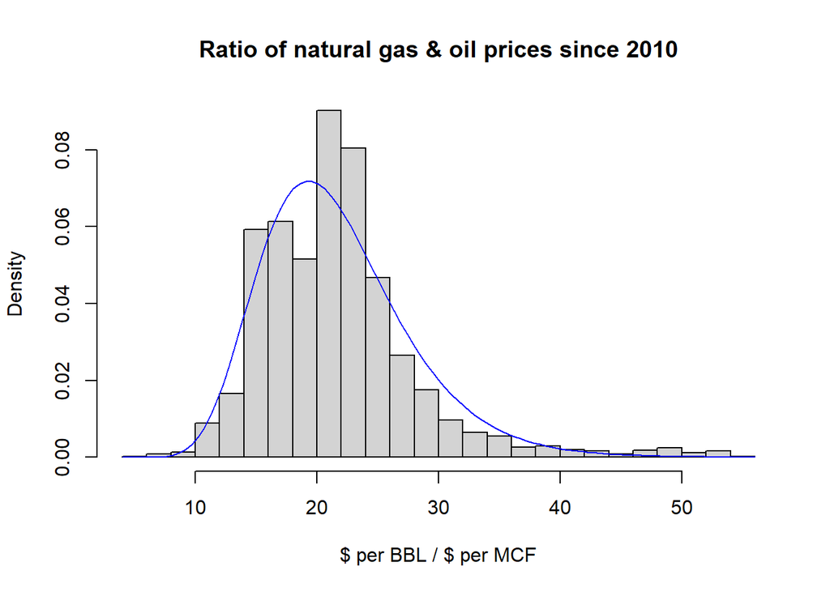

```r
daily_prices[year>2010, {hist(ratio_BBLpMCF, freq=FALSE, breaks="scott", main="", xlab="");
                        curve(dlnorm(x, mean(log(ratio_BBLpMCF)), sd(log(ratio_BBLpMCF))), add=TRUE, col="blue");
                        title(main="Ratio of natural gas & oil prices since 2010", xlab="$ per BBL / $ per MCF"); NULL}]
```

Kitzmueller & Shimshack 2012 cite that consumers paid a premium of about 16% for green power products and furthermore that they are willing to pay a premium of 5-20% for renewable electricity.

```r
# Lower bound
daily_prices[, summary(dollars_pMCF*1.05)]
```

| Min. | 1st Qu. | Median | Mean | 3rd Qu. | Max. |
| --- | --- | --- | --- | --- | --- |
| 1.143293 | 2.863675 | 3.800086 | 4.531973 | 5.672909 | 20.12195 |

```r
# Upper bound
daily_prices[, summary(dollars_pMCF*1.2)]
```

| Min. | 1st Qu. | Median | Mean | 3rd Qu. | Max. |
| --- | --- | --- | --- | --- | --- |
| 1.30662 | 3.272772 | 4.342956 | 5.179397 | 6.483324 | 22.99651 |

```r
# Average
daily_prices[, summary(dollars_pMCF*1.16)]
```

| Min. | 1st Qu. | Median | Mean | 3rd Qu. | Max. |
| --- | --- | --- | --- | --- | --- |
| 1.263066 | 3.16368 | 4.198191 | 5.00675 | 6.267213 | 22.22996 |

Output price data

```r
fwrite(daily_prices, "./processed/daily_prices.csv")
```

# Demand Function

[Natural gas (Henry Hub) prices](https://www.eia.gov/dnav/ng/NG_PRI_FUT_S1_M.htm), [Natural gas marketed production](https://www.eia.gov/dnav/ng/hist/n9050us2m.htm)

```r
monthly_price <- fread("./data/Henry_Hub_Natural_Gas_Spot_Price.csv")

monthly_quantity <- fread("./data/U.S._Natural_Gas_Marketed_Production.csv")
```

### Combine historical prices, quantites, & supply

```r
demand_data <- na.omit(monthly_price[monthly_quantity, on="Month"])
demand_data[, c("Date","Month"):= .(as.Date(paste0("01", Month), "%d %b %Y"), NULL)]
demand_data[, "year":= as.numeric(format(Date, "%Y"))]
demand_data[, "month":= factor(format(Date, "%b"), levels=month.abb)]

demand_data[month %in% c("Mar", "Apr", "May"), "season":= "spring"]
demand_data[month %in% c("Jun", "Jul", "Aug"), "season":= "summer"]
demand_data[month %in% c("Sep", "Oct", "Nov"), "season":= "fall"]
demand_data[month %in% c("Dec", "Jan", "Feb"), "season":= "winter"]

setnames(demand_data, "Henry Hub Natural Gas Spot Price Dollars per Million Btu", "p")
setnames(demand_data, "U.S. Natural Gas Marketed Production  Million Cubic Feet", "q")

demand_data[, "p":= p * 1.037]          # convert to dollars per MCF
demand_data[, "q":= 1000*as.numeric(q)] # convert to MCF
```

Rolling yearly minimum prices

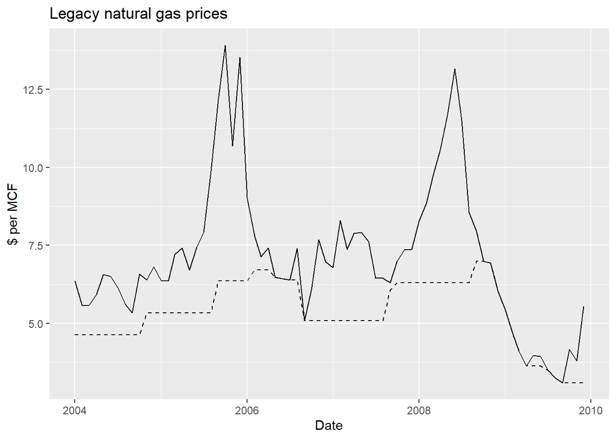

```r
demand_data[order(Date), "threshold":= frollapply(p, 12, min, na.rm=TRUE)]

ggplot(demand_data[year>2003 & year<2010], aes(x=Date)) +
    geom_line(aes(y=p)) +
    geom_line(aes(y=threshold), lty=2) +
    labs(title="Legacy natural gas prices", y="$ per MCF")
```

Flag time-series outliers

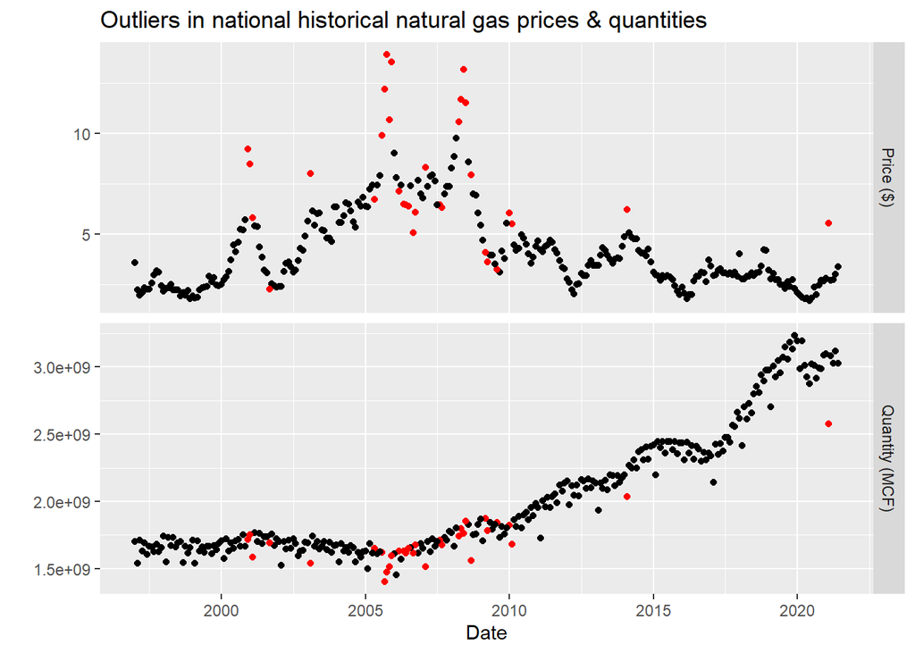

```r
demand_data[, "outlier":= {rem = p/q - supsmu(1:.N, p/q)$y; rem_lim = boxplot.stats(rem)$stats;
                            !between(rem, min(rem_lim), max(rem_lim))}]

ggplot(melt(demand_data, measure.vars=c("p","q")), aes(x=Date, y=value, color=outlier)) +
    geom_point(show.legend=FALSE) +
    scale_color_manual(values=c("black", "red")) +
    facet_grid(variable~., scales="free_y", labeller=labeller(variable=c("q"="Quantity (MCF)", "p"="Price ($)"))) +
    labs(title="Outliers in national historical natural gas prices & quantities", y="")
```

### Price-quantity relationship

All-time natural gas demand

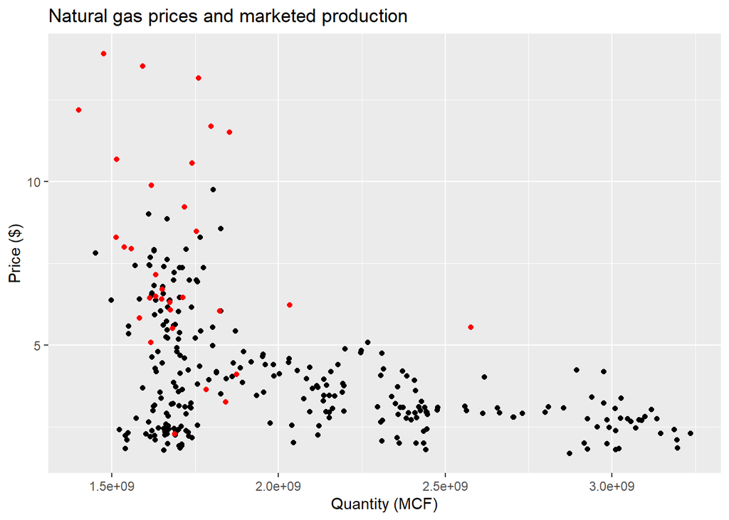

```r
ggplot(demand_data, aes(x=q, y=p)) +
    geom_point() +
    geom_point(data=demand_data[outlier==TRUE], color="red") +
    labs(title="Natural gas prices and marketed production", x="Quantity (MCF)", y="Price ($)")
```

Seasonal natural gas demand

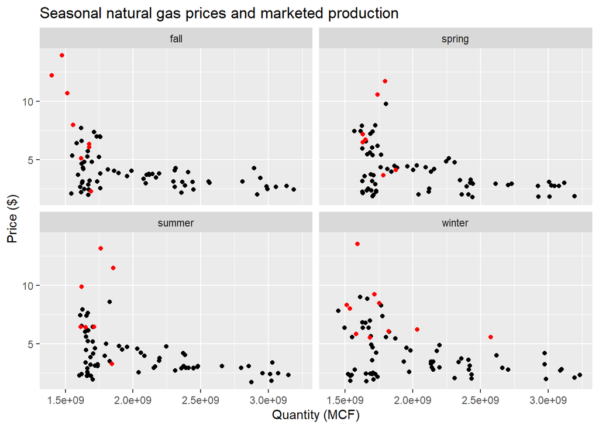

```r
ggplot(demand_data, aes(x=q, y=p)) +
    geom_point() +
    geom_point(data=demand_data[outlier==TRUE], color="red") +
    facet_wrap(~season) +
    labs(title="Seasonal natural gas prices and marketed production", x="Quantity (MCF)", y="Price ($)")
```

Monthly natural gas demand

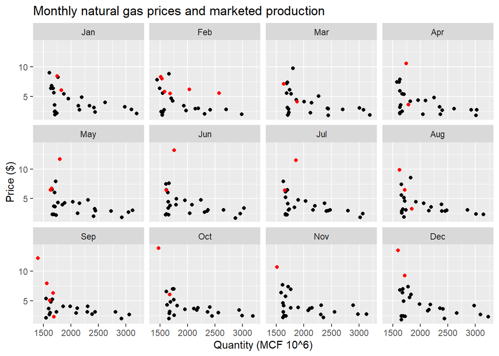

```r
ggplot(demand_data, aes(x=q, y=p)) +
    geom_point() +
    geom_point(data=demand_data[outlier==TRUE], color="red") +
    scale_x_continuous(labels = function(x) x/1e6) +
    facet_wrap(~month) +
    labs(title="Monthly natural gas prices and marketed production", x="Quantity (MCF 10^6)", y="Price ($)")
```

### Linear fit to cleaned monthly data

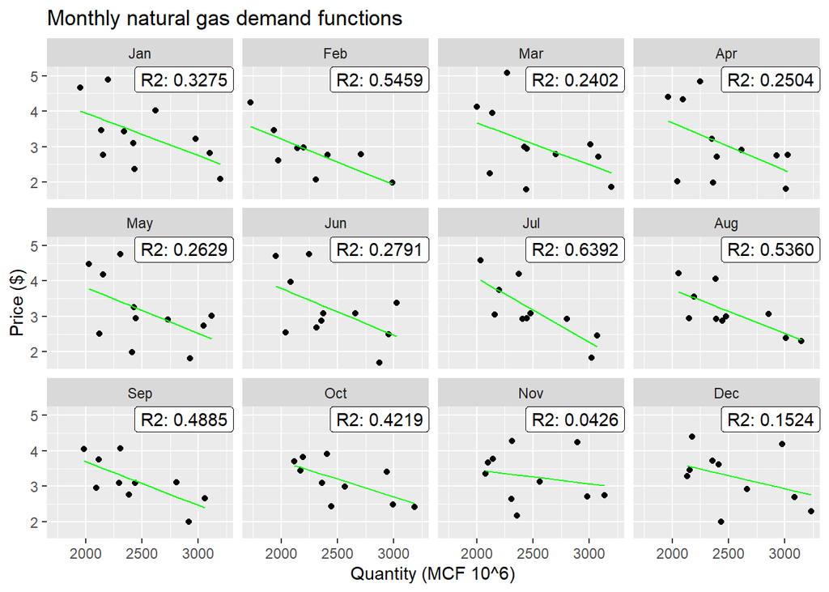

```r
fit_data <- demand_data[year>2010][outlier==FALSE, .(p, q), by=month]
curve_data <- fit_data[, .("model"= .(lm(p~q, .SD))), by=month]
fit_data[curve_data, on="month", "lfit":= predict(model[[1]], .("q"=q)), by=.EACHI]

ggplot(fit_data, aes(x=q, y=p)) +
    geom_point() +
    geom_line(aes(y=lfit), color="green") +
    scale_x_continuous(labels = function(x) x/1e6) +
    geom_label(data=curve_data[, .("R2"=summary(model[[1]])$r.squared), by=month],
                aes(label=sprintf("R2: %.4f", R2), x=Inf, y=Inf), hjust=1, vjust=1) +
    facet_wrap(.~month) +
    labs(title="Monthly natural gas demand functions", x="Quantity (MCF 10^6)", y="Price ($)")
```

### Proportion of national supply from Texas

[Texas natural gas marketed production](https://www.eia.gov/dnav/ng/hist/n9050tx2m.htm)

```r
monthly_quantity_TX   <- fread("./data/Texas_Natural_Gas_Marketed_Production.csv")
monthly_quantity_TX[, "Date":= as.Date(paste0("01", Month), "%d %b %Y")]

demand_data[monthly_quantity_TX, on="Date", "q_TX":= 1000 * `Texas Natural Gas Marketed Production  Million Cubic Feet`]
```

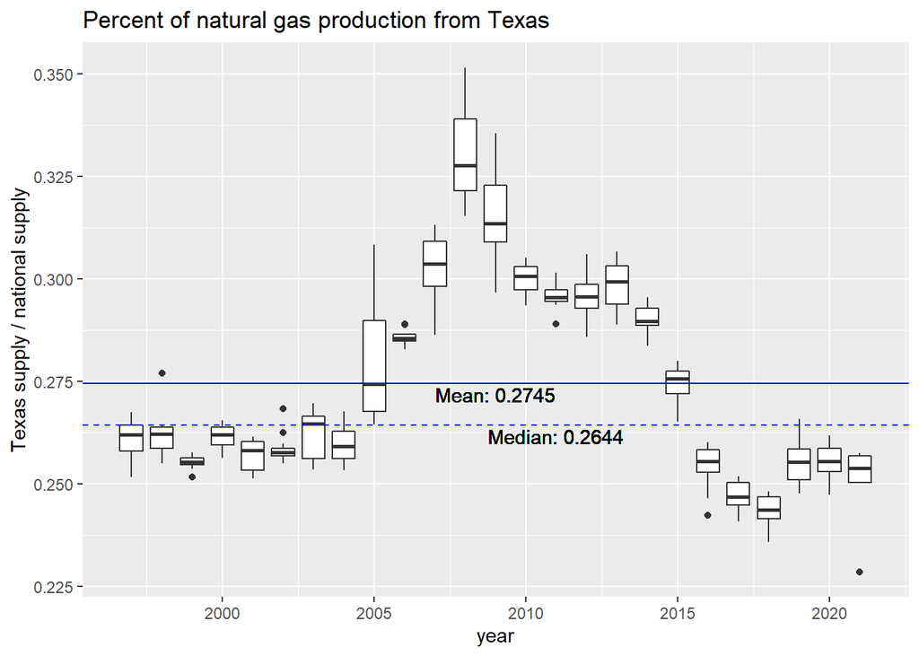

Texas production accounts for about ~1/4 of national gas supply

```r
ggplot(demand_data) +
    geom_boxplot(aes(x=year, y=q_TX/q, group=year)) +
    geom_hline(aes(yintercept=mean(q_TX/q)), color="blue") +
    geom_text(aes(x=2009, y=mean(q_TX/q)*0.99,
                label=sprintf("Mean: %.4f", mean(q_TX/q)))) +
    geom_hline(aes(yintercept=median(q_TX/q)), color="blue", lty="dashed") +
    geom_text(aes(x=2011, y=median(q_TX/q)*0.99,
                label=sprintf("Median: %.4f", median(q_TX/q)))) +
    labs(title="Percent of natural gas production from Texas", y="Texas supply / national supply")
```

Output representative demand data

```r
fwrite(demand_data[outlier==FALSE & between(year,2010,2020), .(p, q, q_TX), by= .(month,year)],
        "./processed/historical_NG_demand.csv")
```

### Consumption by sector (residential, industrial, exported)

```r
monthly_quantity_sector <- read_xls("./data/NG_CONS_SUM_DCU_NUS_M.xls", sheet="Data 1", skip=2)
setDT(monthly_quantity_sector)

monthly_quantity_sector[, "Month":= format(Date, "%h %Y")]

# merge quantity exported
monthly_exports <- fread("./data/U.S._Natural_Gas_Exports.csv")

monthly_quantity_sector[monthly_exports, on="Month", "exported_MMCF":= `U.S. Natural Gas Exports  Million Cubic Feet`]

monthly_quantity_sector[gsub(" .*", "", Date) >= "2001-01-01",
    c("percent_residential", "percent_industrial", "percent_exported"):=
    .(`U.S. Natural Gas Residential Consumption (MMcf)` / `Natural Gas Delivered to Consumers in the U.S. (MMcf)`,
    `U.S. Natural Gas Industrial Consumption (MMcf)` / `Natural Gas Delivered to Consumers in the U.S. (MMcf)`,
    exported_MMCF / `Natural Gas Delivered to Consumers in the U.S. (MMcf)`)]
```

```r
monthly_quantity_sector[year(Date)>=2001, {print("Residential:");
                                            print(summary(percent_residential));
                                            print("Industrial");
                                            print(summary(percent_industrial));
                                            print("Exported");
                                            summary(percent_exported)}]
```

```
## [1] "Residential:"
##    Min. 1st Qu.  Median    Mean 3rd Qu.    Max.
## 0.04637 0.08409 0.16621 0.18813 0.28889 0.38989
## [1] "Industrial"
##    Min. 1st Qu.  Median    Mean 3rd Qu.    Max.
##  0.2297  0.2907  0.3253  0.3248  0.3579  0.4345
## [1] "Exported"
```

| Min. | 1st Qu. | Median | Mean | 3rd Qu. | Max. |
| --- | --- | --- | --- | --- | --- |
| 0.0101984 | 0.0407964 | 0.0561006 | 0.0795718 | 0.0989135 | 0.3096014 |

Output demand by sector

```r
fwrite(monthly_quantity_sector, "./processed/monthly_quantity_sector.csv")
```

# Green electricity premiums

[Utility prices](https://www.eia.gov/electricity/sales_revenue_price/)

Format names of [major green energy utilities](https://www.nrel.gov/analysis/assets/pdfs/green-pricing-top-10-2020-data-plus-archives.pdf) for which premium data (below) is also available.

```r
utility_base_price <- read_xlsx("./data/f8612017_table6.xlsx", skip=2)
setDT(utility_base_price)

# Names of major green energy utilities for which premium data is available
utility_base_price[Entity=="Portland General Electric Co",      "utility":= "Portland General Electric"]
utility_base_price[Entity=="PacifiCorp",                        "utility":= "PacifiCorp"]
utility_base_price[Entity %in% c("Northern States Power Co - Wisconsin", "Northern States Power Co - Minnesota",
                                "Public Service Co of Colorado",
                                "Southwestern Public Service Co",
                                "Cheyenne Light Fuel & Power Co"),
                    "utility":= "Xcel Energy"]
utility_base_price[Entity=="Sacramento Municipal Util Dist",    "utility":= "Sacramento Municipal Utility District"]
utility_base_price[Entity=="Puget Sound Energy Inc",            "utility":= "Puget Sound Energy"]
utility_base_price[Entity=="Virginia Electric & Power Co",      "utility":= "Dominion"]
utility_base_price[Entity=="DTE Electric Company",              "utility":= "DTE Energy"]
utility_base_price[Entity=="Austin Energy",                     "utility":= "Austin Energy"]
utility_base_price[Entity %in% c("Granite State Electric Co",
                                "Massachusetts Electric Co",
                                "Nantucket Electric Co",
                                "The Narragansett Electric Co"),
                    "utility":= "National Grid"]
utility_base_price[Entity %in% c("New York State Elec & Gas Corp", "Rochester Gas & Electric Corp"),
                    "utility":= "Avangrid"]
```

Percent premium using the mean residential premium per kWh.

```r
utility_base_price[, "approx_percent_premium":= 1.6 / `Average Price (cents/kWh)`]

summary(1.6 / utility_base_price[!is.na(utility), `Average Price (cents/kWh)`])
```

| Min. | 1st Qu. | Median | Mean | 3rd Qu. | Max. |
| --- | --- | --- | --- | --- | --- |
| 0.065931 | 0.1148988 | 0.1364702 | 0.1270189 | 0.1423308 | 0.1763563 |

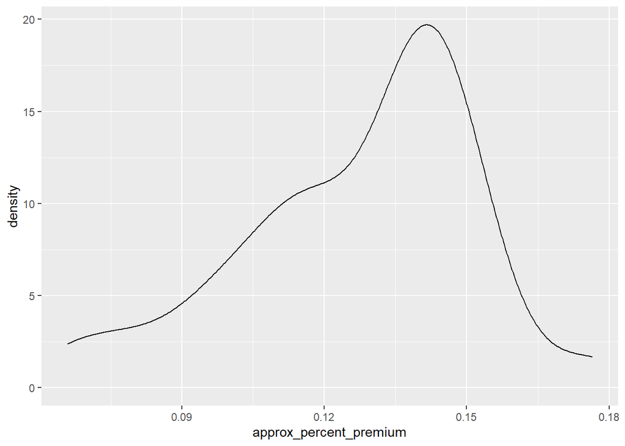

```r
ggplot(utility_base_price[!is.na(utility)]) +
    geom_density(aes(approx_percent_premium))
```

Green power [programs](https://www.nrel.gov/analysis/green-power.html) (2022 pricing data)

```r
utility_premium_price <- read_xlsx("./data/utility-green-pricing-program-list.xlsx", skip=4)
setDT(utility_premium_price)

utility_premium_price[, "premium_cpkWh":= as.numeric(gsub(". per kWh", "", .SD[[5]]))]
# missing values
utility_premium_price[Utility=="Austin Energy", "premium_cpkWh":= 0.75]

utility_premium_price[utility_base_price[!is.na(utility)], on=c("State", "Utility"="utility"),
    "base_cpkWh":= `Average Price (cents/kWh)`]
utility_premium_price[utility_base_price[!is.na(utility)], on=c("State", "Parent Utility"="utility"),
    "base_cpkWh":= `Average Price (cents/kWh)`]
# crude matching of Tennessee Valley Authority
utility_premium_price[utility_base_price, on=c("State", "Utility"="Entity"),
    "base_cpkWh":= ifelse(grepl("TVA", `Parent Utility`), `Average Price (cents/kWh)`, base_cpkWh)]

utility_premium_price[!is.na(base_cpkWh), "premium_percent":= premium_cpkWh / base_cpkWh]
```

```r
summary(utility_premium_price[!is.na(premium_percent), premium_percent])
```

| Min. | 1st Qu. | Median | Mean | 3rd Qu. | Max. |
| --- | --- | --- | --- | --- | --- |
| 0.0701171 | 0.163811 | 0.2330961 | 0.2027539 | 0.2524626 | 0.3006677 |

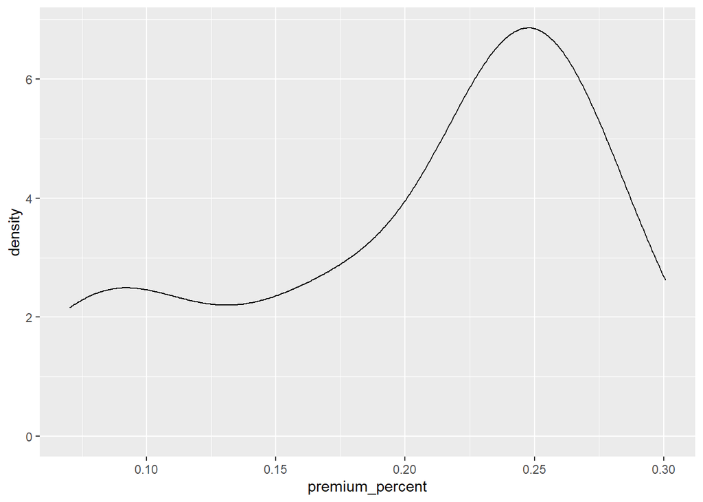

```r
ggplot(utility_premium_price[!is.na(premium_percent)]) +
    geom_density(aes(premium_percent))
```